# ICE Annina 10x sequencing analysis - ML predictions of human/organoid cross-dataset comparisson

Author

Vladyslav Korobeynyk at Jessberger/Robinsonlab, UZH

Published

September 17, 2026

**Note**

In this script we are modelling patient’s Age for the human data, and cross-testing them against the organoid data and iNeuron (and vice versa).

**What this script does:** trains glmnet models in both directions between the human and organoid metacell data and evaluates cross-dataset generalization: (1) train a gaussian Age-predictor on human metacells, test it on each organoid dataset/timepoint (COp1 10w, COp1 4m, COp2 4dpi, COp2 4wpi, for both IN and EN); (2) train a binomial WT-vs-ICE classifier on organoid metacells (using genes selected from the organoid DEA results), test it on human metacells to see if the phenotype score tracks chronological age; (3) train a gaussian Age-predictor on human metacells and test it on an external induced-neuron (“iNeurons”) dataset. All models are trained once per dataset combination (not repeated across seeds, unlike `03_human_ML_predictions_human.qmd`) since the goal here is cross-dataset generalization, not within-dataset variability.

# Setup

```r
options(future.globals.maxSize = 8000 * 1024^2)
suppressMessages({
  library(scater)
  library(dplyr)
  library(purrr)
  library(parallel)
  library(ggpubr)
  library(ggplot2)
  library(stringr)
  library(magrittr)
  library(SingleCellExperiment)
  library(glmnet)
  library(knitr)
  library(DT)
  library(ggsignif)
})
source(params$helper_functions_path)
dir.create(params$human_output_dir, recursive = TRUE, showWarnings = FALSE)
dir.create(params$organoid_output_dir, recursive = TRUE, showWarnings = FALSE)

set.seed(1)
```

# Load data

```r
# -----#
# IN
# -----#
metacell_human_IN = readRDS(file.path(params$metacell_dir, "metacell_sce_IN_human.RDS"))
metadata_metacell_IN = colData(metacell_human_IN)
DEA_metacell_IN = read.csv(file.path(params$dea_dir, "DEA_metacell_iN_old_vs_young.csv"), row.names = 1)

# make sure none of the genes is constantly 0
keep = which(rowSums(logcounts(metacell_human_IN)) > 0) %>% names
metacell_human_IN = metacell_human_IN[keep, ]

# -----#
# EN
# -----#
metacell_human_EN = readRDS(file.path(params$metacell_dir, "metacell_sce_EN_human.RDS"))
metadata_metacell_human_EN = colData(metacell_human_EN)
DEA_metacell_EN = read.csv(file.path(params$dea_dir, "DEA_metacell_exN_old_vs_young.csv"), row.names = 1)

# make sure none of the genes is constantly 0
keep = which(rowSums(logcounts(metacell_human_EN)) > 0) %>% names
metacell_human_EN = metacell_human_EN[keep, ]
```

# Helper functions for this script

```r
#' Keep genes with count >= min_count in at least min_fraction_metacells of metacells
filter_genes_min_expression = function(sce, min_count = params$min_gene_count,
                                        min_fraction_metacells = params$min_fraction_metacells_expressing) {
  keep = rowSums(counts(sce) >= min_count) >= (min_fraction_metacells * ncol(sce))
  sce[keep, ]
}

#' Restrict two SCEs to their shared genes (order-independent, returns both)
restrict_to_common_genes = function(sce_a, sce_b) {
  common_genes = intersect(rownames(sce_a), rownames(sce_b))
  list(a = sce_a[common_genes, ], b = sce_b[common_genes, ])
}

#' Train a gaussian Age-predictor on human metacells, test on an organoid metacell dataset
#'
#' @param human_sce human metacell SingleCellExperiment (used as-is; not modified in place)
#' @param organoid_rds_path path to the organoid metacell .RDS
#' @param nested_sce TRUE if the RDS stores the SCE under a $sce element (as COp2 files do)
#'   rather than being the SCE itself (as COp1 files are)
#' @param label short label for this comparison, e.g. "IN_10w"
#' @return data.frame of predictions on the organoid data
train_human_test_organoid = function(human_sce, organoid_rds_path, nested_sce, label) {

  human_train = filter_genes_min_expression(human_sce)

  organoid = readRDS(organoid_rds_path)
  if (nested_sce) organoid = organoid$sce

  restricted = restrict_to_common_genes(human_train, organoid)
  human_train = restricted$a
  organoid = restricted$b

  scaled_counts_human = as.data.frame(scale(t(logcounts(human_train))))
  scaled_counts_organoid = as.data.frame(scale(t(logcounts(organoid))))

  data = scaled_counts_human
  data$label = human_train$Age

  # train model with gaussian family on all human data; n_times not used here (single fixed model)
  out = train_glmnet_model(df = data, model_family = "gaussian", n_times = 1, test = FALSE)

  preds = predict(out$cvfit, newx = as.matrix(scaled_counts_organoid), s = "lambda.min", type = "response")

  preds_df = data.frame(
    predictions_organoids = as.vector(preds),
    true_organoid_age = organoid$phenotype,
    datasets_predicted = label,
    dataset = organoid$dataset
  )

  print(
    ggplot(preds_df, aes(x = true_organoid_age, y = predictions_organoids, fill = dataset)) +
      geom_boxplot(color = "skyblue") +
      labs(y = "Predicted Age", x = "True Age") +
      theme_bw()
  )

  preds_df
}

#' Train a binomial WT-vs-ICE classifier on organoid metacells (genes selected from the
#' organoid DEA), test on human metacells
#'
#' @param organoid_rds_path path to the organoid metacell .RDS (COp1 files, not nested)
#' @param organoid_dea_csv_path path to the organoid ICE-vs-wt DEA results, used to select
#'   which genes go into the model (padj < params$dea_padj_threshold, excluding the mCherry gene)
#' @param human_sce human metacell SingleCellExperiment (used as-is; not modified in place)
#' @param label short label for this comparison, e.g. "IN_human_10w"
#' @return data.frame of predictions on the human data
train_organoid_test_human = function(organoid_rds_path, organoid_dea_csv_path, human_sce, label) {

  genenames_model = read.csv(organoid_dea_csv_path, row.names = 1) %>%
    filter(padj < params$dea_padj_threshold, gene != "p23031-mCherry") %>%
    pull(gene) %>%
    unique()

  organoid = readRDS(organoid_rds_path)
  organoid_train = organoid[rownames(organoid) %in% genenames_model, ]

  restricted = restrict_to_common_genes(organoid_train, human_sce)
  organoid_train = restricted$a
  human_local = restricted$b

  scaled_counts_organoid = as.data.frame(scale(t(logcounts(organoid_train))))
  scaled_counts_human = as.data.frame(scale(t(logcounts(human_local))))

  data = scaled_counts_organoid
  data$label = organoid_train$phenotype

  # train model with binomial family on all organoid data; n_times not used here (single fixed model)
  out = train_glmnet_model(df = data, model_family = "binomial", n_times = 1, test = FALSE)

  preds = predict(out$cvfit, newx = as.matrix(scaled_counts_human), s = "lambda.min", type = "response")

  preds_df = data.frame(
    predictions_human = as.vector(preds),
    true_human_age = human_local$Age,
    datasets_predicted = label,
    Diagnosis = human_local$Diagnosis,
    Sex = human_local$Sex,
    Sample_Source = human_local$Sample_Source
  )

  for (covariate in c("Diagnosis", "Sex", "Sample_Source")) {
    print(
      ggplot(preds_df, aes(x = true_human_age, y = predictions_human, color = .data[[covariate]])) +
        geom_point(alpha = 0.3) +
        geom_smooth(se = FALSE) +
        facet_wrap(vars(.data[[covariate]])) +
        theme_light() +
        ylab("Prediction probability for wt (young organoid)")
    )
  }

  preds_df
}

#' Train a gaussian Age-predictor on human metacells, test on the external iNeurons dataset
#'
#' @param human_sce human metacell SingleCellExperiment (used as-is; not modified in place)
#' @param ineurons_rds_path path to the iNeurons edgeR object (its $sg element is used)
#' @param label short label used in the plot title, e.g. "EN" or "IN"
#' @return data.frame of predictions on the iNeurons data
train_human_test_iNeurons = function(human_sce, ineurons_rds_path, label) {

  human_train = filter_genes_min_expression(human_sce)

  iNeurons = readRDS(ineurons_rds_path)$sg

  # restrict to the age range covered by the human training data
  iNeurons = iNeurons[, iNeurons$age > min(human_train$Age) & iNeurons$age < max(human_train$Age)]

  # remove genes with missing/duplicated symbols, and genes with 0 counts across all samples
  iNeurons = iNeurons[!is.na(rowData(iNeurons)$symbol) & !duplicated(rowData(iNeurons)$symbol)]
  iNeurons = iNeurons[rowSums(assay(iNeurons, "counts")) > 0, ]
  rownames(iNeurons) = rowData(iNeurons)$symbol

  restricted = restrict_to_common_genes(human_train, iNeurons)
  human_train = restricted$a
  iNeurons = restricted$b

  scaled_counts_human = as.data.frame(scale(t(logcounts(human_train))))
  scaled_counts_iNeurons = as.data.frame(scale(t(assay(iNeurons, "logcpm"))))

  data = scaled_counts_human
  data$label = human_train$Age

  # train model with gaussian family on all human data; n_times not used here (single fixed model)
  out = train_glmnet_model(df = data, model_family = "gaussian", n_times = 1, test = FALSE)

  preds = predict(out$cvfit, newx = as.matrix(scaled_counts_iNeurons), s = "lambda.min", type = "response")

  preds_df = data.frame(
    predictions_iNeurons = as.vector(preds),
    true_organoid_age = iNeurons$age,
    dataset = iNeurons$condition
  )

  print(
    ggplot(preds_df, aes(x = true_organoid_age, y = predictions_iNeurons)) +
      geom_point(color = "skyblue") +
      geom_smooth(method = "lm", color = "black", linetype = "dashed") +
      labs(y = "Predicted Age", x = "True Age") +
      stat_regline_equation(aes(label = ..rr.label..), show.legend = FALSE) +
      ggtitle(paste0("Predicted vs chronological Age per iNeuron batch | ", label)) +
      theme_bw()
  )

  preds_df
}
```

# Train human data | test organoids

**IN_COp1_10w**

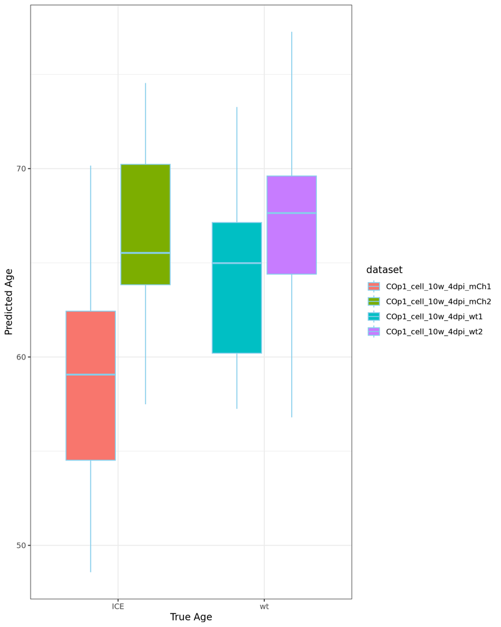

**EN_COp1_10w**

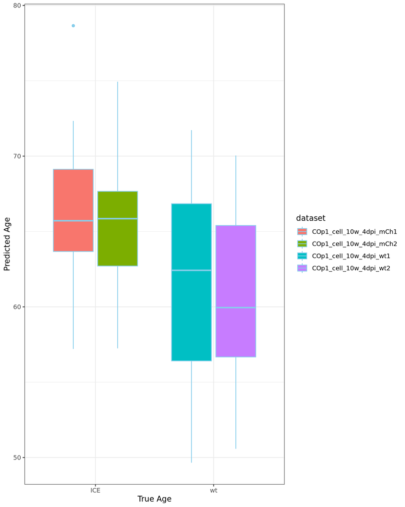

**IN_COp1_4m**

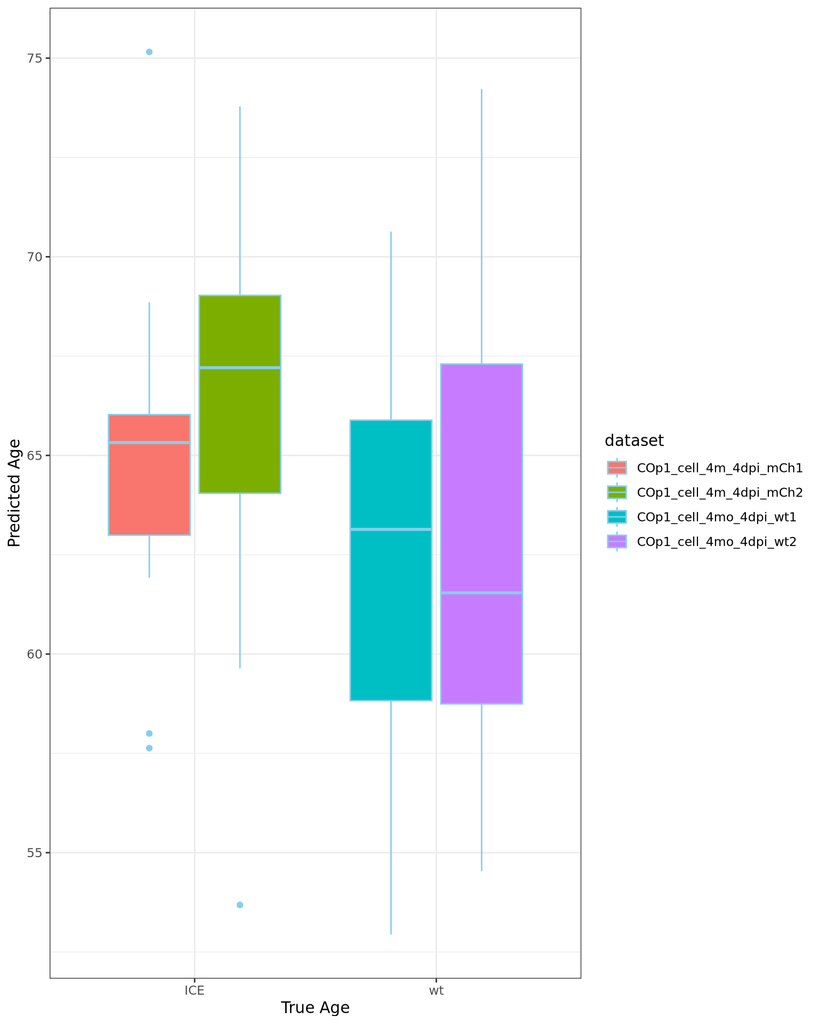

**EN_COp1_4m**

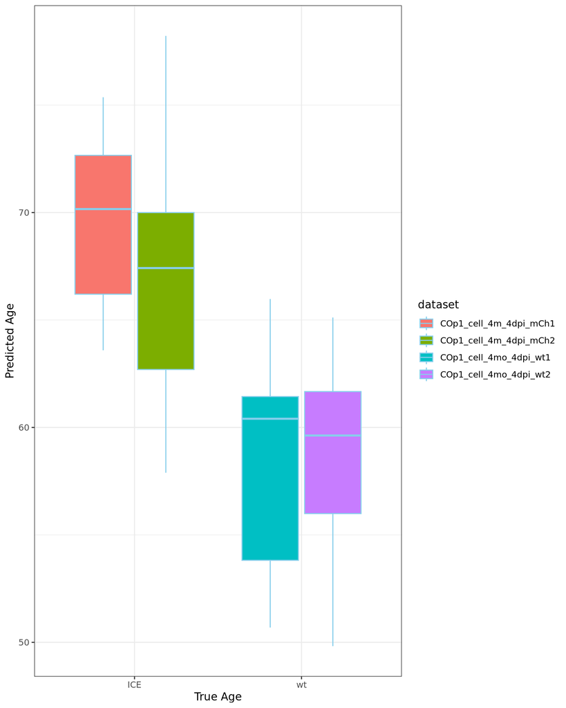

**EN_COp2_4dpi**

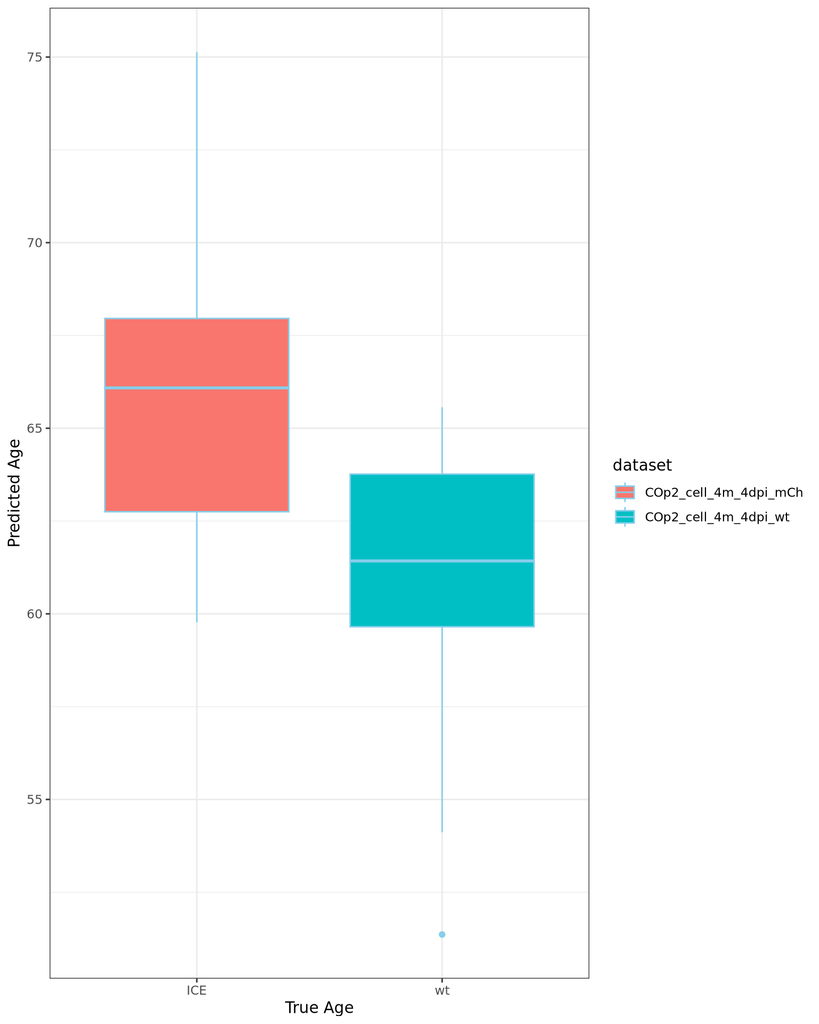

**IN_COp2_4dpi**

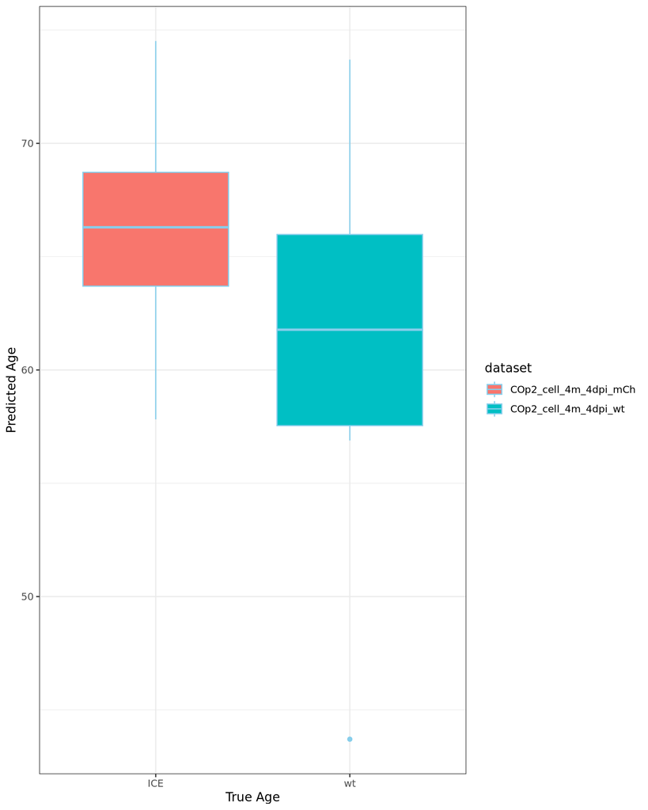

**EN_COp2_4wpi**

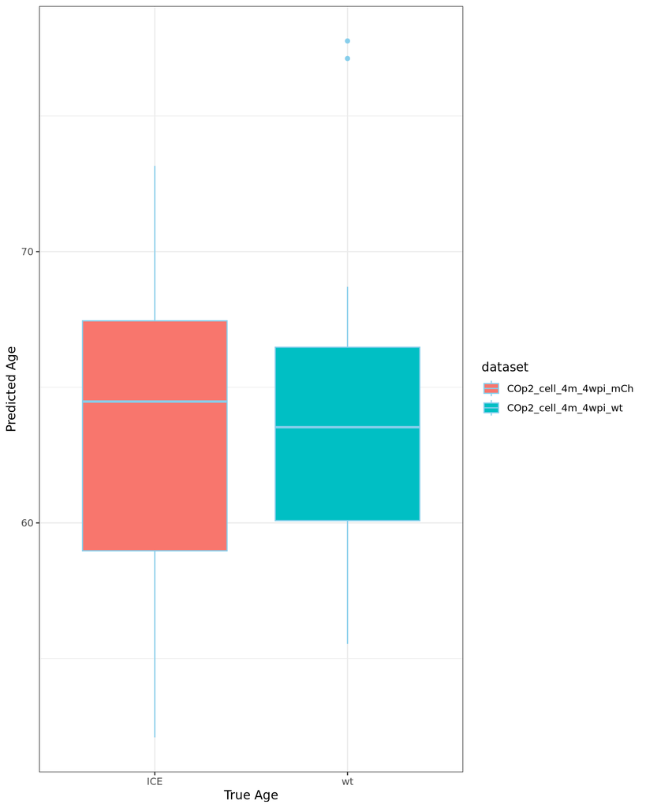

**IN_COp2_4wpi**

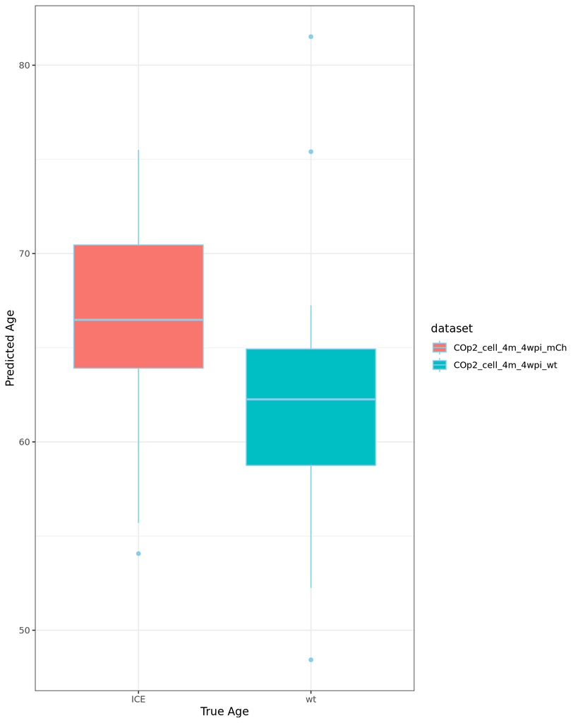

# Prediction summary (human -> organoids)

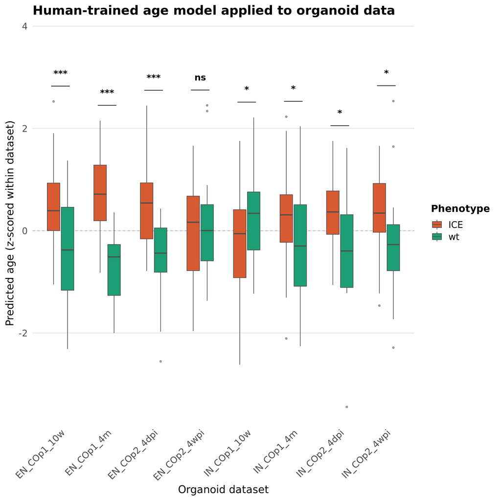

```r
df = do.call(rbind, preds_organoids)

# Standardize within each dataset
df = df %>%
  group_by(datasets_predicted) %>%
  mutate(predictions_organoids_z = as.numeric(scale(predictions_organoids))) %>%
  ungroup()

write.table(df, file.path(params$organoid_output_dir, "prediction_summary_trainHuman_testOrganoids.txt"))

# Ensure consistent dataset ordering between the test results and the main plot
dataset_levels = df %>% distinct(datasets_predicted) %>% arrange(datasets_predicted) %>% pull(datasets_predicted)
df$datasets_predicted = factor(df$datasets_predicted, levels = dataset_levels)

# Wilcoxon test: ICE vs wt, on the RAW (non-z-scored) predicted age, per dataset
sig_results = df %>%
  dplyr::group_by(datasets_predicted) %>%
  dplyr::summarise(
    p_value = wilcox.test(predictions_organoids ~ true_organoid_age)$p.value,
    max_z = max(predictions_organoids_z, na.rm = TRUE),
    .groups = "drop"
  ) %>%
  dplyr::mutate(
    p_label = case_when(
      p_value < 0.001 ~ "***",
      p_value < 0.01  ~ "**",
      p_value < 0.05  ~ "*",
      TRUE ~ "ns"
    ),
    x_numeric = as.numeric(datasets_predicted),
    xmin = x_numeric - 0.2,
    xmax = x_numeric + 0.2,
    xmid = x_numeric,
    y_bracket = max_z + 0.3,
    y_text = max_z + 0.55
  )

ggplot(df, aes(x = datasets_predicted, y = predictions_organoids_z, fill = true_organoid_age)) +
  geom_hline(yintercept = 0, linetype = "dashed", color = "gray70", linewidth = 0.4) +
  geom_boxplot(width = 0.6, outlier.size = 1, outlier.alpha = 0.5, linewidth = 0.4, color = "gray30") +
  geom_segment(data = sig_results, aes(x = xmin, xend = xmax, y = y_bracket, yend = y_bracket), inherit.aes = FALSE, linewidth = 0.4) +
  geom_text(data = sig_results, aes(x = xmid, y = y_text, label = p_label), inherit.aes = FALSE, size = 4.5, fontface = "bold") +
  scale_fill_manual(values = c(ICE = "#D85A30", wt = "#1D9E75")) +
  scale_y_continuous(expand = expansion(mult = c(0.05, 0.15))) +
  labs(
    title = "Human-trained age model applied to organoid data",
    x = "Organoid dataset",
    y = "Predicted age (z-scored within dataset)",
    fill = "Phenotype"
  ) +
  theme_minimal(base_size = 16) +
  theme(
    plot.title = element_text(size = 18, face = "bold", hjust = 0),
    panel.grid.minor = element_blank(),
    panel.grid.major.x = element_blank(),
    axis.text.x = element_text(angle = 45, hjust = 1, size = 13),
    axis.text.y = element_text(size = 13),
    axis.title = element_text(size = 15),
    legend.title = element_text(size = 14, face = "bold"),
    legend.text = element_text(size = 13),
    legend.position = "right"
  )
```

# Train organoid data | test human

**COp1_IN_10w**

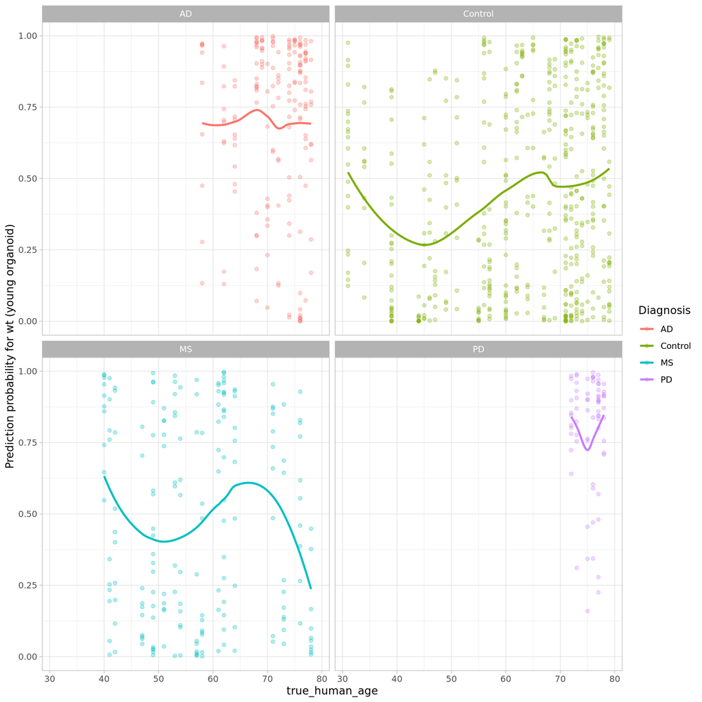

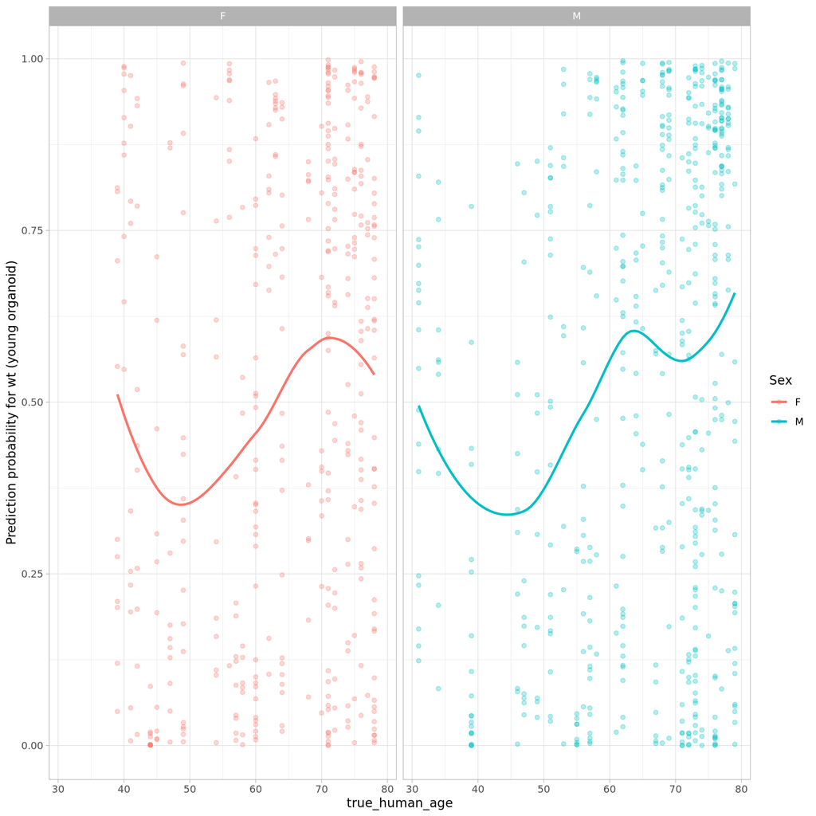

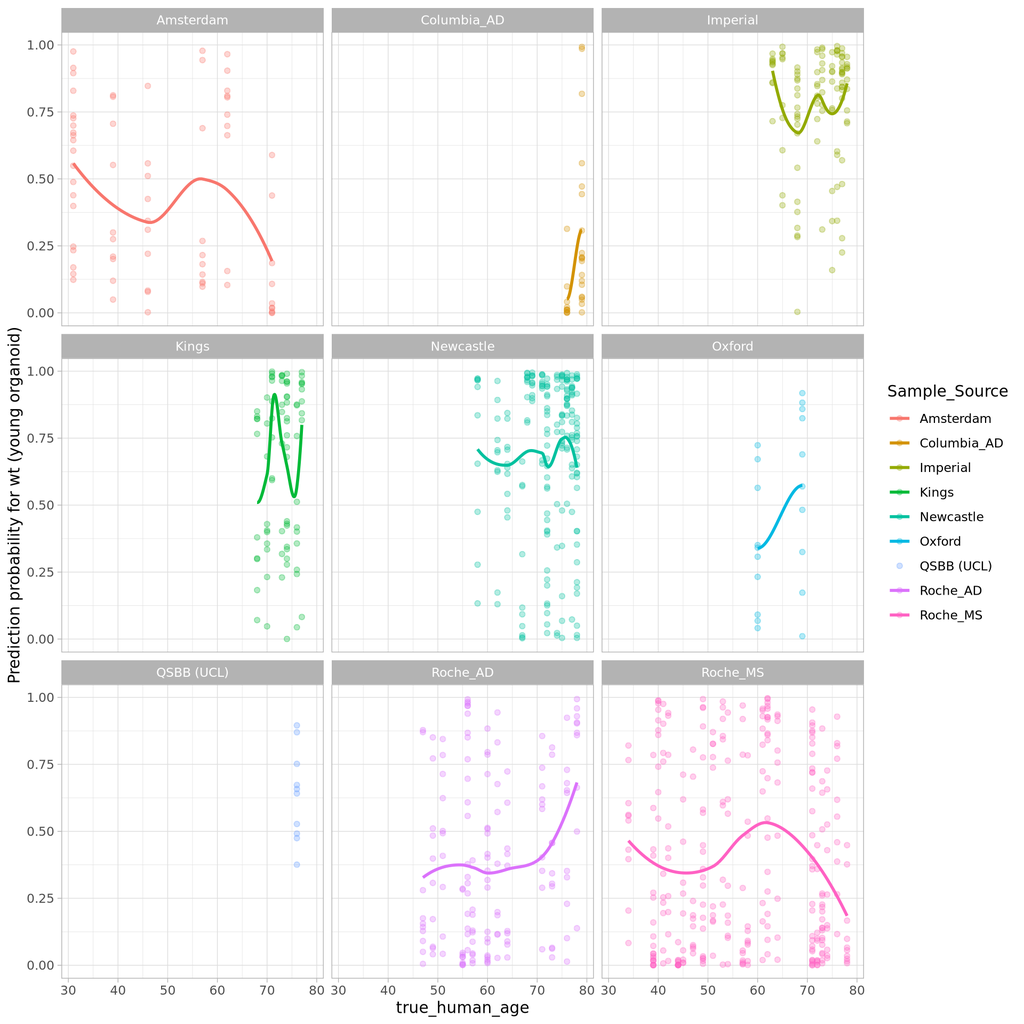

**COp1_EN_10w**

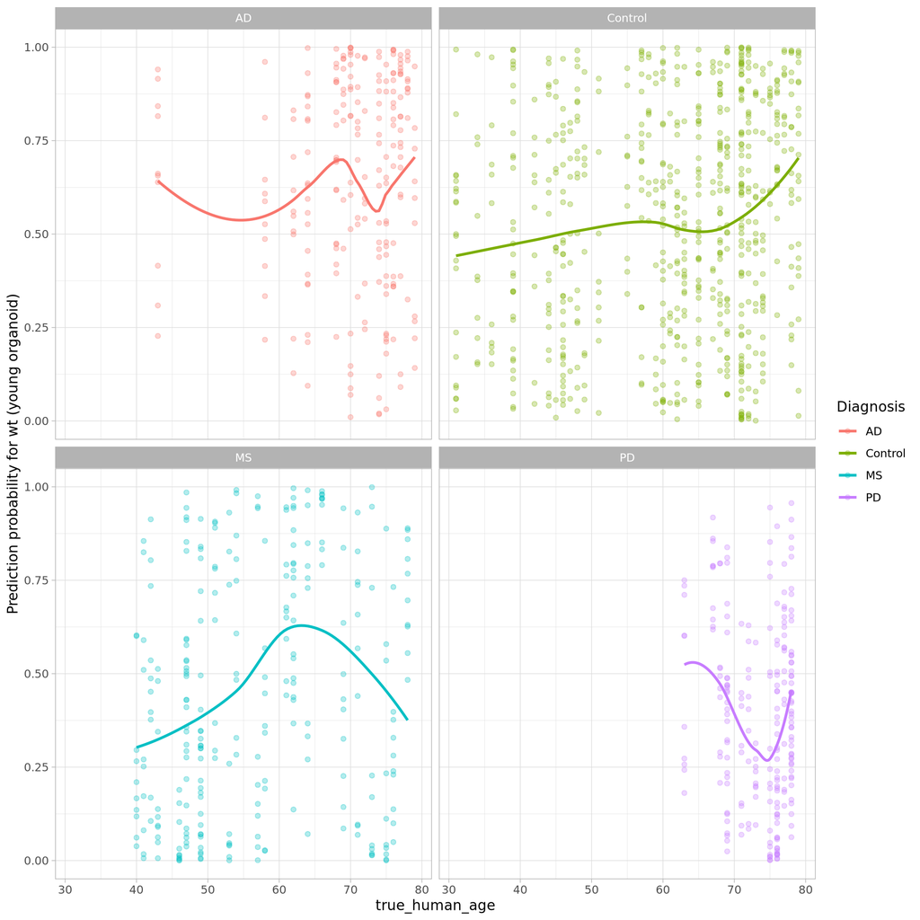

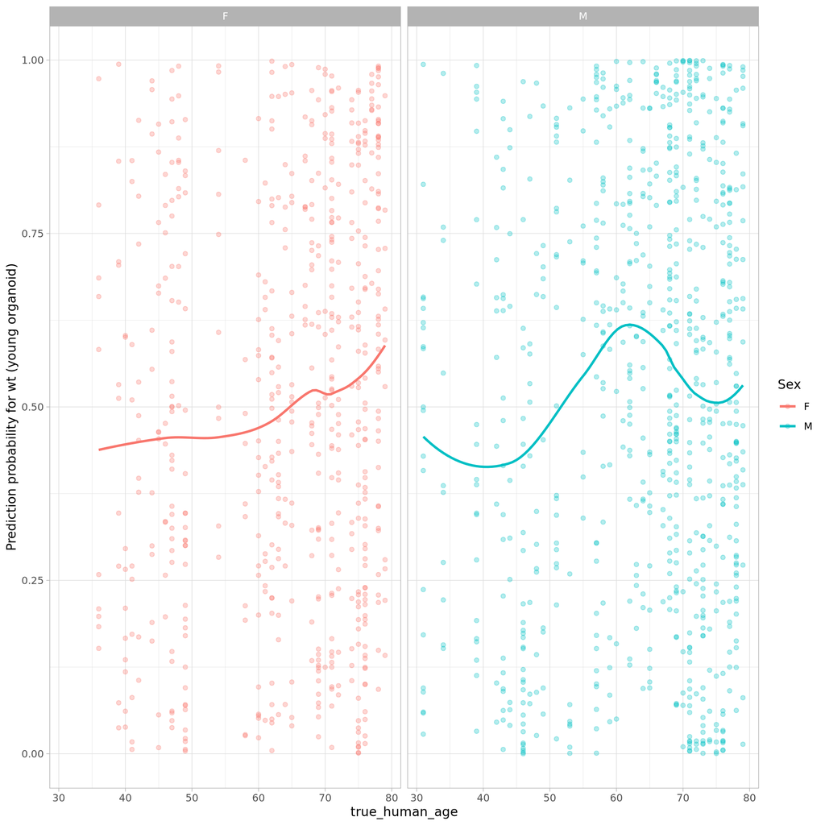

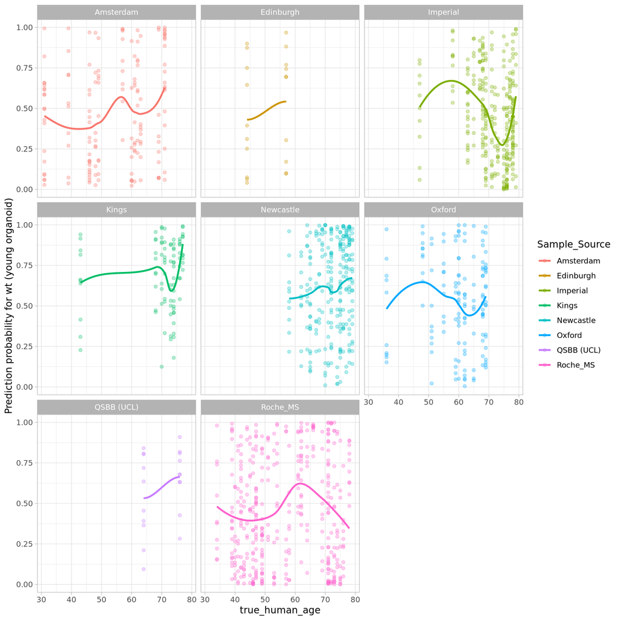

**COp1_IN_4m**

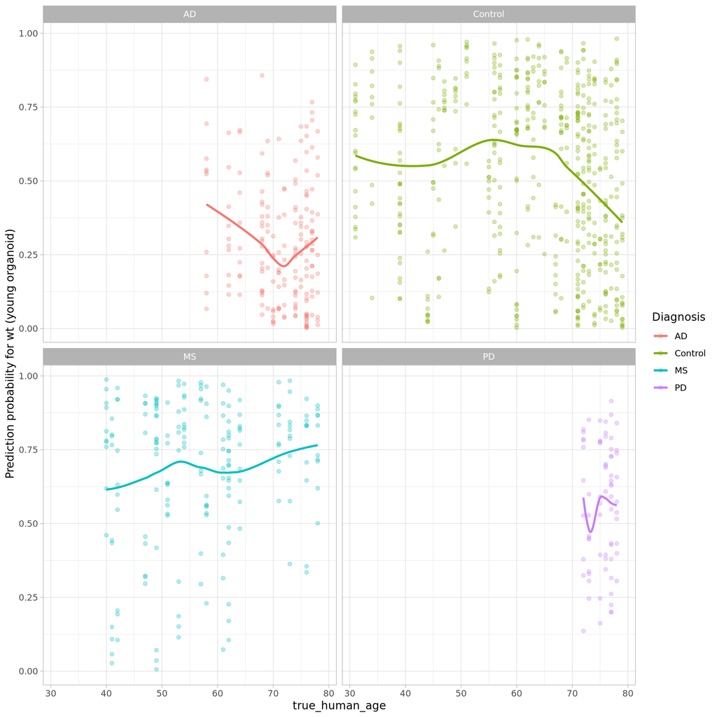

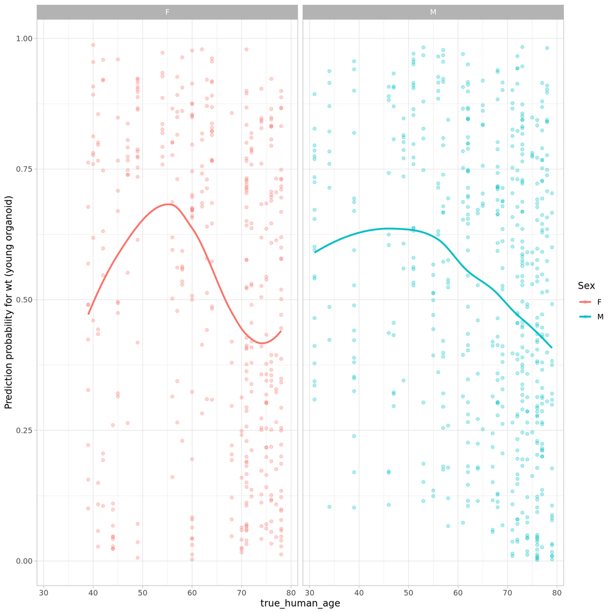

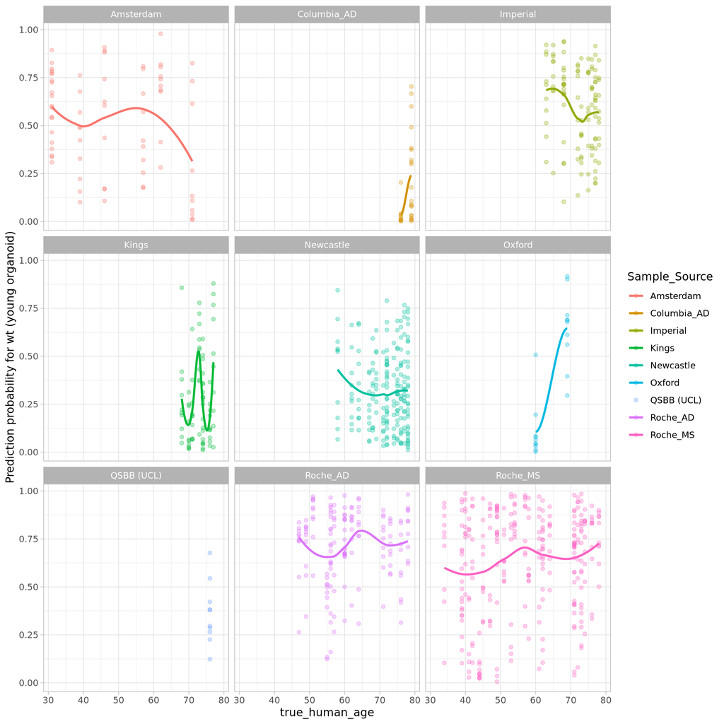

**COp1_EN_4m**

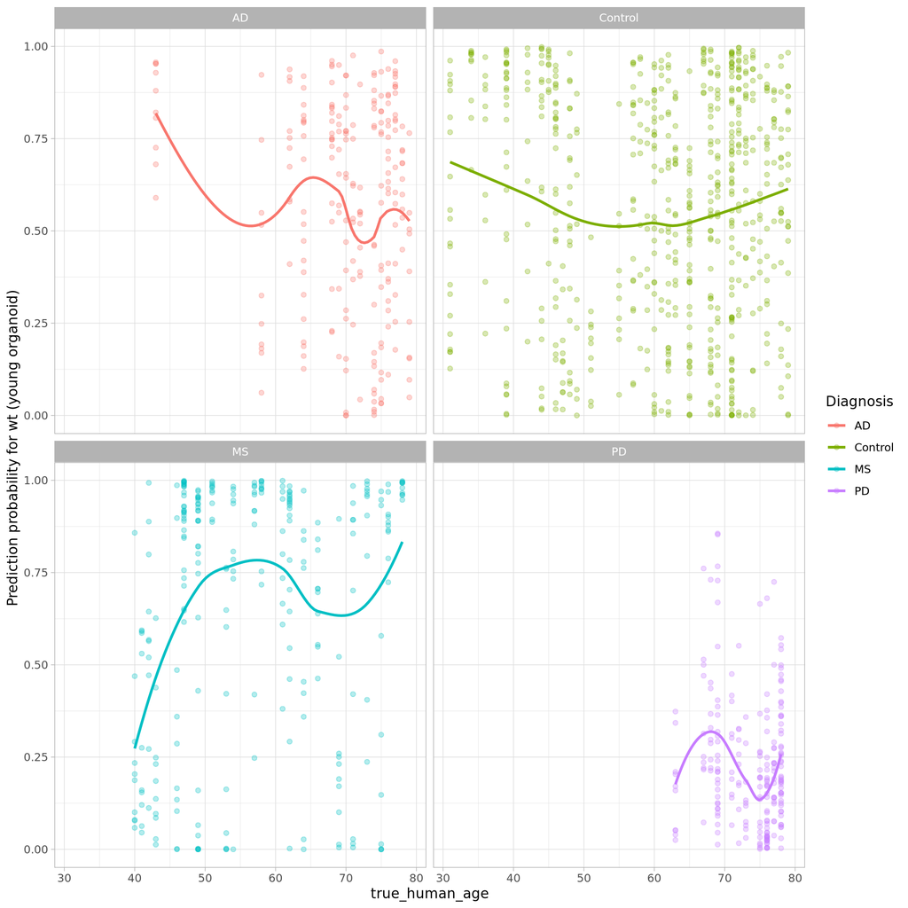

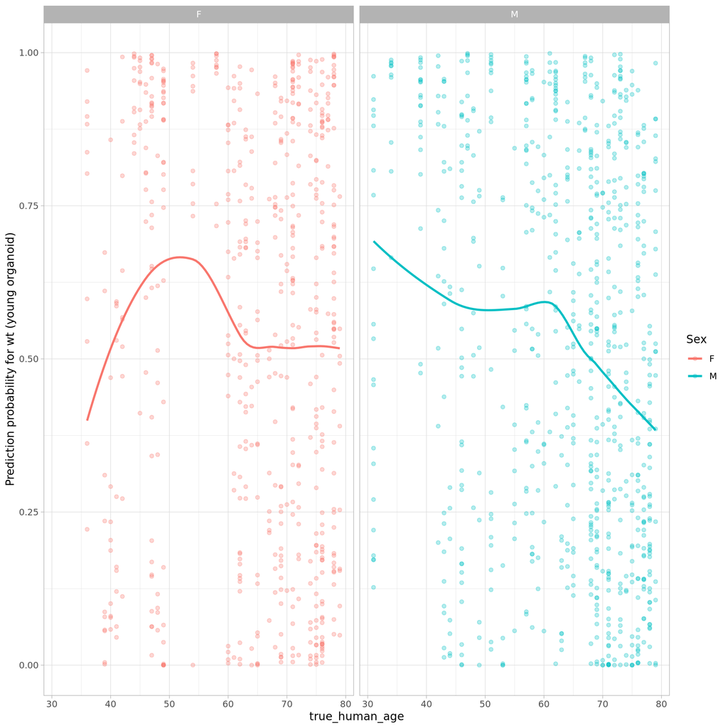

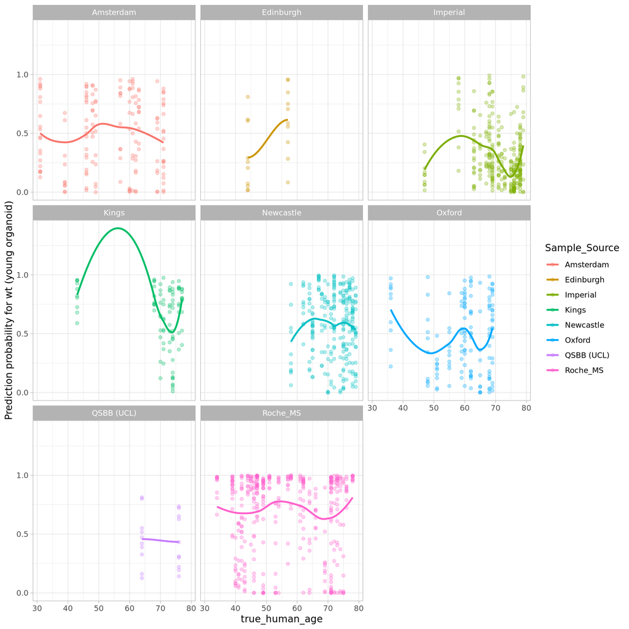

# Prediction summary (organoids -> human)

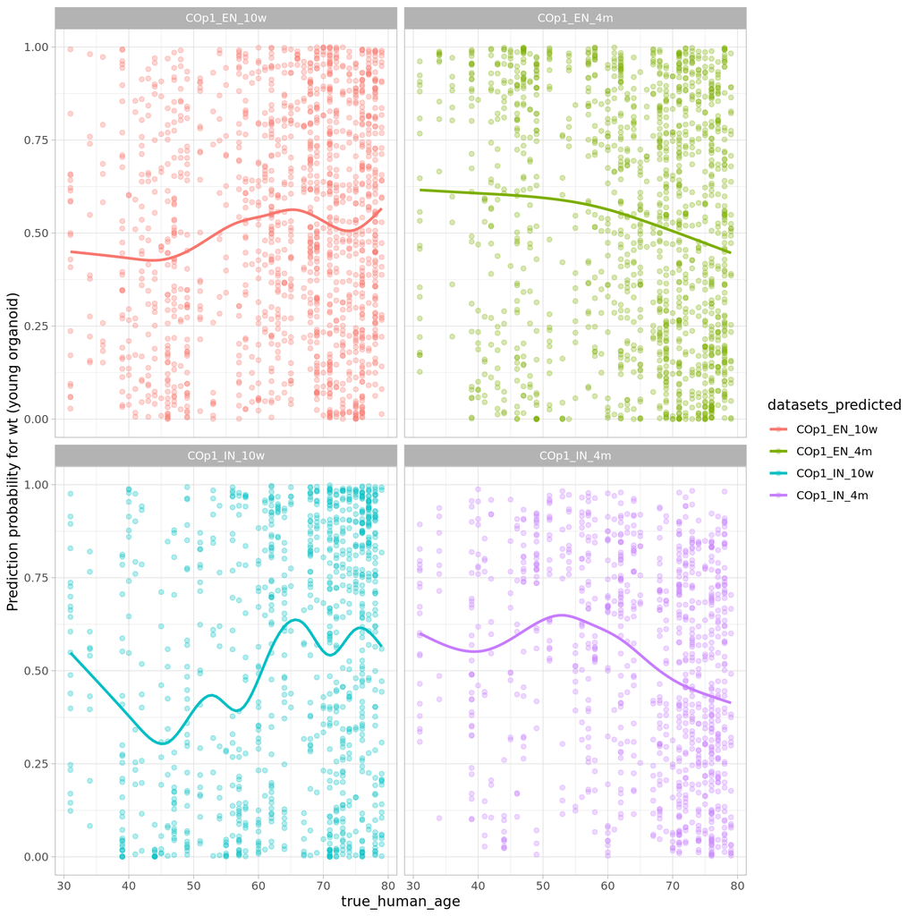

```r
df = do.call(rbind, preds_human)

write.table(df, file.path(params$human_output_dir, "prediction_summary_trainOrganoid_testHuman.txt"))

ggplot(df, aes(x = true_human_age, y = predictions_human, color = datasets_predicted)) +
  geom_point(alpha = 0.3) +
  geom_smooth(se = FALSE) +
  facet_wrap(~datasets_predicted) +
  theme_light() +
  ylab("Prediction probability for wt (young organoid)")
```

# Train human data | test iNeurons

**EN**

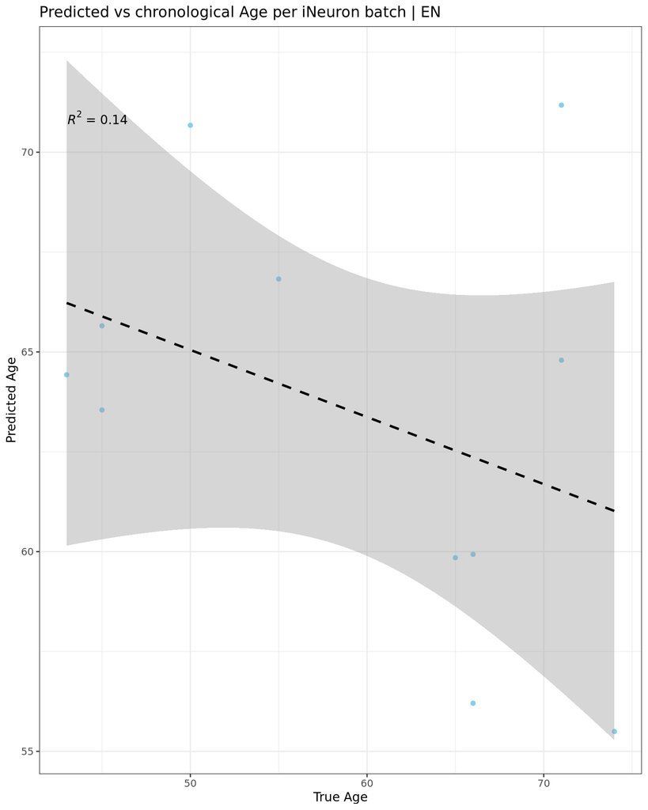

```r
preds_iNeurons_EN = train_human_test_iNeurons(
  human_sce = metacell_human_EN, ineurons_rds_path = params$ineurons_path, label = "EN"
)
```

**IN**

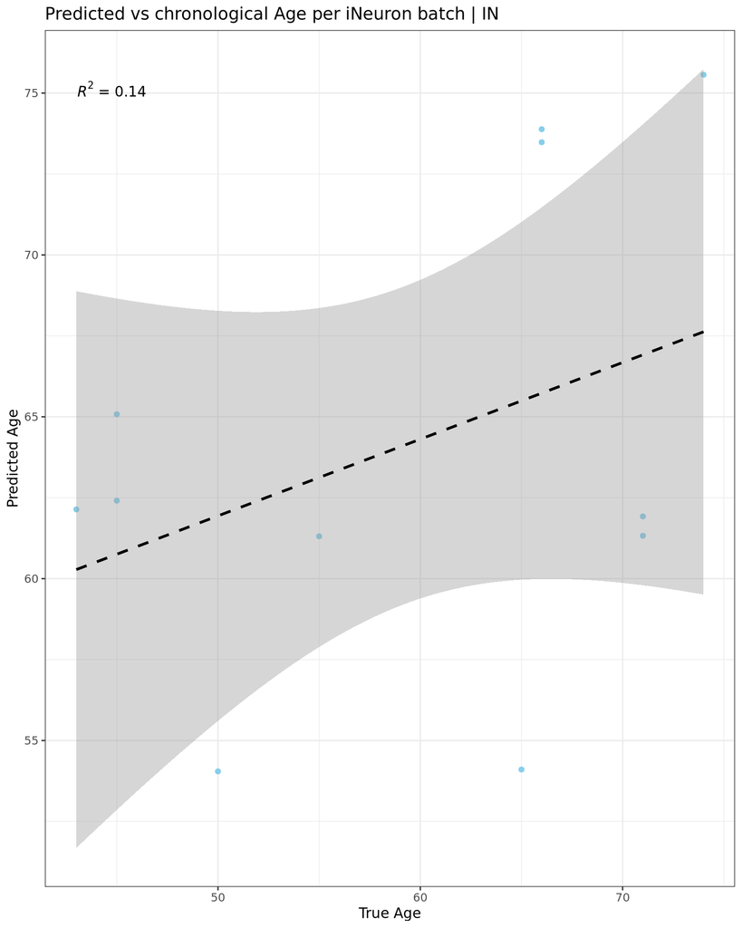

```r
preds_iNeurons_IN = train_human_test_iNeurons(
  human_sce = metacell_human_IN, ineurons_rds_path = params$ineurons_path, label = "IN"
)
```